[figure not shown]

# Practical 06: Data Visualisation

Dr. Todd Jones

t.r.jones@reading.ac.uk

**Department of Computer Science**

Follow the instructions to complete each of these tasks.

This set of exercises focuses on practicing implementation of data visualisation tools from `pandas`, `matplotlib`, and `seaborn`.

This work is not assessed but will help you gain practical experience for the coursework.

You will have accessed this practical notebook by downloading a `.zip` file containing the relevant datasets. The **relative path** to the data from this notebook should be: `./data/<dataset_file_name>`

Please refer back to the **Data Visualisation lecture notebook** for internet references to various routines and packages.

Where **additional materials**, not covered in the lecture, are required, they are implemented for you or referenced below.

```python
# You will need these tools
import pandas as pd
import numpy as np
import matplotlib.pyplot as plt
import seaborn as sns
```

# Histograms

Look at the **`./data/faithful.csv`** data, which gives a list of eruptions of a geyser in Yellowstone National Park in the USA. The **`eruptions`** variable gives the temporal length of the eruption, while the **`waiting`** variable gives the waiting time until the next eruption. One "source" on this very commonly explored dataset: https://stat.ethz.ch/R-manual/R-devel/library/datasets/html/faithful.html

- Explore the data by looking at the **distribution** of the two variables.
  - Which kinds of plots look at distributions?
  - Try out `plt.hist()`, `sns.histplot()`, and `sns.jointplot()`.
- How do they **vary together**?
- What do you notice about the distribution of the individual variables?
- Are they related?

```python
# Simple read of the data
data = pd.read_csv('./data/faithful.csv')
data.head()
```

|  | eruptions | waiting |
| --- | --- | --- |
| 1 | 3.600 | 79 |
| 2 | 1.800 | 54 |
| 3 | 3.333 | 74 |
| 4 | 2.283 | 62 |
| 5 | 4.533 | 85 |

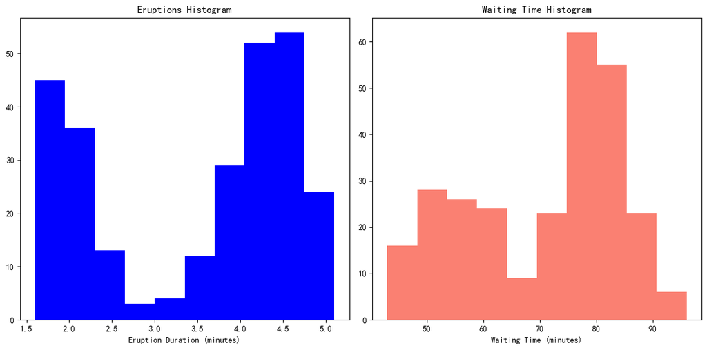

```python
# Simple histogram with matplotlib
plt.figure(figsize=(12, 6))
plt.subplot(1, 2, 1)
plt.hist(data['eruptions'], color='blue')
plt.title('Eruptions Histogram')
plt.xlabel('Eruption Duration (minutes)')

plt.subplot(1, 2, 2)
plt.hist(data['waiting'],  color='salmon')
plt.title('Waiting Time Histogram')
plt.xlabel('Waiting Time (minutes)')

plt.tight_layout()
plt.show()
```

[figure not shown]

```python
# Use sns.histplot
plt.figure(figsize=(12, 6))

plt.subplot(1, 3, 1)
sns.histplot(data['eruptions'], kde=True, color='skyblue')
plt.title('Seaborn Histplot of Eruptions')

plt.subplot(1, 3, 2)
sns.histplot(data['waiting'], kde=True, color='salmon')
plt.title('Seaborn Histplot of Waiting Time')

plt.tight_layout()
plt.show()
```

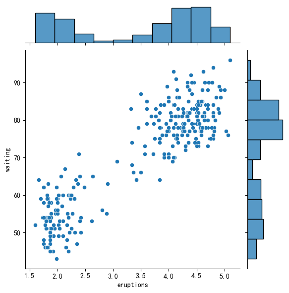

```python
# use jointplot to show the relationship between eruptions and waiting time
sns.jointplot(data=data, x='eruptions', y='waiting')
plt.show()
```

# Hong Kong Marine Water Quality

Hong Kong government open data: historical marine water quality

- Measurements of various **water quality** indicators in

different monitoring stations.

- Data is split up into different zones.
- Data is measured at different times in different zones.

**Source:** https://data.gov.hk/en-data/dataset/hk-epd-marineteam-marine-water-quality-historical-data-en

**Data:** `./data/marine-historical-2021-en.csv`

**Description:** `./data/historical_marine_data_dictionary_en.pdf`

## Read Data

Read the data and explore its contents.

```python
file = './data/marine-historical-2021-en.csv'
data = pd.read_csv(file)
```

```python
data
```

|  | Water Control Zone | Station | Dates | Sample No | Depth | 5-day Biochemical Oxygen Demand (mg/L) | Ammonia Nitrogen (mg/L) | Chlorophyll-a (μg/L) | Dissolved Oxygen (%saturation) | Dissolved Oxygen (mg/L) | ... | Silica (mg/L) | Suspended Solids (mg/L) | Temperature (°C) | Total Inorganic Nitrogen (mg/L) | Total Kjeldahl Nitrogen (mg/L) | Total Nitrogen (mg/L) | Total Phosphorus (mg/L) | Turbidity (NTU) | Unionised Ammonia (mg/L) | Volatile Suspended Solids (mg/L) |
| --- | --- | --- | --- | --- | --- | --- | --- | --- | --- | --- | --- | --- | --- | --- | --- | --- | --- | --- | --- | --- | --- |
| 0 | Deep Bay | DM1 | 2021-02-27 | 1 | Surface Water | 1.4 | 0.460 | 4.1 | 72 | 5.7 | ... | 4.4 | 25 | 21.5 | 1.91 | 0.76 | 2.21 | 0.26 | 36.1 | 0.003 | 2.7 |
| 1 | Deep Bay | DM1 | 2021-03-24 | 1 | Surface Water | 12 | 0.270 | 14 | 70 | 5.5 | ... | 6.1 | 20 | 21.0 | 1.43 | 0.81 | 1.97 | 0.14 | 9.8 | 0.003 | 3.8 |
| 2 | Deep Bay | DM1 | 2021-04-16 | 1 | Surface Water | 2 | 0.260 | 15 | 65 | 4.8 | ... | 5.7 | 19 | 24.6 | 0.99 | 0.82 | 1.55 | 0.2 | 11.6 | 0.008 | 4 |
| 3 | Deep Bay | DM1 | 2021-05-17 | 1 | Surface Water | 1.4 | 0.220 | 14 | 57 | 4.0 | ... | 1.4 | 21 | 30.7 | 0.82 | NaN | NaN | NaN | 25.1 | 0.003 | 9.4 |
| 4 | Deep Bay | DM1 | 2021-06-16 | 1 | Surface Water | 2.1 | 0.410 | 1.7 | 56 | 4.0 | ... | 4.3 | 51 | 30.1 | 1.48 | NaN | NaN | NaN | 37.1 | 0.007 | <0.5 |
| ... | ... | ... | ... | ... | ... | ... | ... | ... | ... | ... | ... | ... | ... | ... | ... | ... | ... | ... | ... | ... | ... |
| 2703 | Western Buffer | WT3 | 2021-09-06 | 1 | Middle Water | 1.1 | 0.058 | 10 | 62 | 4.1 | ... | 0.92 | 4.2 | 27.4 | 0.22 | NaN | NaN | NaN | 4.2 | 0.001 | 1.2 |
| 2704 | Western Buffer | WT3 | 2021-09-06 | 1 | Bottom Water | 0.5 | 0.050 | 5.7 | 59 | 4.0 | ... | 1.3 | 4.8 | 26.3 | 0.23 | NaN | NaN | NaN | 4.7 | <0.001 | 3.6 |
| 2705 | Western Buffer | WT3 | 2021-11-01 | 1 | Surface Water | 0.4 | 0.045 | 1.1 | 88 | 5.9 | ... | 0.86 | 5 | 26.3 | 0.13 | NaN | NaN | NaN | 7.1 | <0.001 | 1.1 |
| 2706 | Western Buffer | WT3 | 2021-11-01 | 1 | Middle Water | 0.4 | 0.046 | 0.9 | 67 | 4.5 | ... | 0.82 | 3.4 | 26.3 | 0.13 | NaN | NaN | NaN | 7.1 | <0.001 | 0.6 |
| 2707 | Western Buffer | WT3 | 2021-11-01 | 1 | Bottom Water | 0.4 | 0.048 | 1.4 | 82 | 5.5 | ... | 0.83 | 4.2 | 26.3 | 0.14 | NaN | NaN | NaN | 7.8 | <0.001 | 0.8 |

2708 rows × 29 columns

```python
data.columns
```

```
Index(['Water Control Zone', 'Station', 'Dates', 'Sample No', 'Depth',
       '5-day Biochemical Oxygen Demand (mg/L)', 'Ammonia Nitrogen (mg/L)',
       'Chlorophyll-a (μg/L)', 'Dissolved Oxygen (%saturation)',
       'Dissolved Oxygen (mg/L)', 'E. coli (cfu/100mL)',
       'Faecal Coliforms (cfu/100mL)', 'Nitrate Nitrogen (mg/L)',
       'Nitrite Nitrogen (mg/L)', 'Orthophosphate Phosphorus (mg/L)', 'pH',
       'Phaeo-pigments (μg/L)', 'Salinity (psu)', 'Secchi Disc Depth (M)',
       'Silica (mg/L)', 'Suspended Solids (mg/L)', 'Temperature (°C)',
       'Total Inorganic Nitrogen (mg/L)', 'Total Kjeldahl Nitrogen (mg/L)',
       'Total Nitrogen (mg/L)', 'Total Phosphorus (mg/L)', 'Turbidity (NTU)',
       'Unionised Ammonia (mg/L)', 'Volatile Suspended Solids (mg/L)'],
      dtype='object')
```

```python
data.info()
```

```
<class 'pandas.core.frame.DataFrame'>
RangeIndex: 2708 entries, 0 to 2707
Data columns (total 29 columns):
 #   Column                                  Non-Null Count  Dtype
---  ------                                  --------------  -----
 0   Water Control Zone                      2708 non-null   object
 1   Station                                 2708 non-null   object
 2   Dates                                   2708 non-null   object
 3   Sample No                               2708 non-null   int64
 4   Depth                                   2708 non-null   object
 5   5-day Biochemical Oxygen Demand (mg/L)  2708 non-null   object
 6   Ammonia Nitrogen (mg/L)                 2708 non-null   float64
 7   Chlorophyll-a (μg/L)                    2708 non-null   object
 8   Dissolved Oxygen (%saturation)          2708 non-null   int64
 9   Dissolved Oxygen (mg/L)                 2708 non-null   float64
```

[output cut: 21 more lines]

```python
data.describe()
```

|  | Sample No | Ammonia Nitrogen (mg/L) | Dissolved Oxygen (%saturation) | Dissolved Oxygen (mg/L) | pH | Salinity (psu) | Secchi Disc Depth (M) | Temperature (°C) | Total Inorganic Nitrogen (mg/L) | Total Nitrogen (mg/L) | Turbidity (NTU) |
| --- | --- | --- | --- | --- | --- | --- | --- | --- | --- | --- | --- |
| count | 2708.0 | 2708.000000 | 2708.000000 | 2708.000000 | 2708.000000 | 2708.000000 | 2708.00000 | 2708.000000 | 2708.000000 | 1214.000000 | 2705.000000 |
| mean | 1.0 | 0.078558 | 72.679099 | 5.054247 | 7.612075 | 31.603028 | 2.93017 | 24.833456 | 0.225391 | 0.685165 | 7.100850 |
| std | 0.0 | 0.091631 | 13.517548 | 0.985105 | 0.245578 | 3.194204 | 1.35502 | 3.257684 | 0.323579 | 0.368913 | 12.718809 |
| min | 1.0 | 0.010000 | 16.000000 | 1.100000 | 6.100000 | 7.100000 | 0.70000 | 16.900000 | 0.010000 | 0.050000 | 0.500000 |
| 25% | 1.0 | 0.030000 | 65.000000 | 4.500000 | 7.500000 | 31.200000 | 2.10000 | 22.100000 | 0.050000 | 0.460000 | 3.300000 |
| 50% | 1.0 | 0.049000 | 71.000000 | 5.000000 | 7.600000 | 32.600000 | 2.60000 | 25.000000 | 0.130000 | 0.640000 | 4.700000 |
| 75% | 1.0 | 0.099000 | 82.000000 | 5.700000 | 7.800000 | 33.400000 | 3.32500 | 27.400000 | 0.290000 | 0.850000 | 7.200000 |
| max | 1.0 | 1.300000 | 157.000000 | 10.200000 | 8.300000 | 34.500000 | 11.30000 | 32.900000 | 5.160000 | 3.490000 | 259.500000 |

## Re-Read Data

- Use the `index_col` parameter to set which input column should be used to represent the `index` of the `DataFrame`.

```python
data = pd.read_csv(file, index_col=2, parse_dates=True)
```

```python
data
```

| Dates | Water Control Zone | Station | Sample No | Depth | 5-day Biochemical Oxygen Demand (mg/L) | Ammonia Nitrogen (mg/L) | Chlorophyll-a (μg/L) | Dissolved Oxygen (%saturation) | Dissolved Oxygen (mg/L) | E. coli (cfu/100mL) | ... | Silica (mg/L) | Suspended Solids (mg/L) | Temperature (°C) | Total Inorganic Nitrogen (mg/L) | Total Kjeldahl Nitrogen (mg/L) | Total Nitrogen (mg/L) | Total Phosphorus (mg/L) | Turbidity (NTU) | Unionised Ammonia (mg/L) | Volatile Suspended Solids (mg/L) |
| --- | --- | --- | --- | --- | --- | --- | --- | --- | --- | --- | --- | --- | --- | --- | --- | --- | --- | --- | --- | --- | --- |
| 2021-02-27 | Deep Bay | DM1 | 1 | Surface Water | 1.4 | 0.460 | 4.1 | 72 | 5.7 | 800 | ... | 4.4 | 25 | 21.5 | 1.91 | 0.76 | 2.21 | 0.26 | 36.1 | 0.003 | 2.7 |
| 2021-03-24 | Deep Bay | DM1 | 1 | Surface Water | 12 | 0.270 | 14 | 70 | 5.5 | 270 | ... | 6.1 | 20 | 21.0 | 1.43 | 0.81 | 1.97 | 0.14 | 9.8 | 0.003 | 3.8 |
| 2021-04-16 | Deep Bay | DM1 | 1 | Surface Water | 2 | 0.260 | 15 | 65 | 4.8 | 66 | ... | 5.7 | 19 | 24.6 | 0.99 | 0.82 | 1.55 | 0.2 | 11.6 | 0.008 | 4 |
| 2021-05-17 | Deep Bay | DM1 | 1 | Surface Water | 1.4 | 0.220 | 14 | 57 | 4.0 | 38 | ... | 1.4 | 21 | 30.7 | 0.82 | NaN | NaN | NaN | 25.1 | 0.003 | 9.4 |
| 2021-06-16 | Deep Bay | DM1 | 1 | Surface Water | 2.1 | 0.410 | 1.7 | 56 | 4.0 | 130 | ... | 4.3 | 51 | 30.1 | 1.48 | NaN | NaN | NaN | 37.1 | 0.007 | <0.5 |
| ... | ... | ... | ... | ... | ... | ... | ... | ... | ... | ... | ... | ... | ... | ... | ... | ... | ... | ... | ... | ... | ... |
| 2021-09-06 | Western Buffer | WT3 | 1 | Middle Water | 1.1 | 0.058 | 10 | 62 | 4.1 | 140 | ... | 0.92 | 4.2 | 27.4 | 0.22 | NaN | NaN | NaN | 4.2 | 0.001 | 1.2 |
| 2021-09-06 | Western Buffer | WT3 | 1 | Bottom Water | 0.5 | 0.050 | 5.7 | 59 | 4.0 | 61 | ... | 1.3 | 4.8 | 26.3 | 0.23 | NaN | NaN | NaN | 4.7 | <0.001 | 3.6 |
| 2021-11-01 | Western Buffer | WT3 | 1 | Surface Water | 0.4 | 0.045 | 1.1 | 88 | 5.9 | 70 | ... | 0.86 | 5 | 26.3 | 0.13 | NaN | NaN | NaN | 7.1 | <0.001 | 1.1 |
| 2021-11-01 | Western Buffer | WT3 | 1 | Middle Water | 0.4 | 0.046 | 0.9 | 67 | 4.5 | 62 | ... | 0.82 | 3.4 | 26.3 | 0.13 | NaN | NaN | NaN | 7.1 | <0.001 | 0.6 |
| 2021-11-01 | Western Buffer | WT3 | 1 | Bottom Water | 0.4 | 0.048 | 1.4 | 82 | 5.5 | 64 | ... | 0.83 | 4.2 | 26.3 | 0.14 | NaN | NaN | NaN | 7.8 | <0.001 | 0.8 |

2708 rows × 28 columns

## Clean Data

Call the `clean_data` function on your `DataFrame` to replace the small value strings with zeros.

```python
# Convert each column to a float
def clean_data(indata):
    '''
    This function will modify the indata DataFrame inplace.

    The HK data has several features that record small numerical values as
    strings that start with "<".

    This code converts data from column 4 onward to floats, replacing
    the small values with zero.
    '''
    for col in indata.columns[4:]:
        if indata[col].dtype == 'object':
            try:
                indata[col] = indata[col].astype(float)
            except Exception as e:
                print(col)
                print('\t', e)

                try:
                    indata[col] = indata[col].where(~indata[col].astype(str).str.startswith('<'), 0)
                    indata[col] = indata[col].astype(float)
                except Exception as e:
                    print('ERROR: Our modification did not work.')
                    print(e)
    print('')
    indata.info()
```

```python
# Calling function to clean the data
clean_data(data)
```

```
5-day Biochemical Oxygen Demand (mg/L)
	 could not convert string to float: '<0.1'
Chlorophyll-a (μg/L)
	 could not convert string to float: '<0.2'
E. coli (cfu/100mL)
	 could not convert string to float: '<1'
Faecal Coliforms (cfu/100mL)
	 could not convert string to float: '<1'
Nitrate Nitrogen (mg/L)
	 could not convert string to float: '<0.002'
Nitrite Nitrogen (mg/L)
	 could not convert string to float: '<0.002'
Orthophosphate Phosphorus (mg/L)
	 could not convert string to float: '<0.002'
Phaeo-pigments (μg/L)
	 could not convert string to float: '<0.2'
Silica (mg/L)
	 could not convert string to float: '<0.05'
Suspended Solids (mg/L)
	 could not convert string to float: '<0.5'
Total Kjeldahl Nitrogen (mg/L)
	 could not convert string to float: '<0.05'
Total Phosphorus (mg/L)
	 could not convert string to float: '<0.02'
Unionised Ammonia (mg/L)
	 could not convert string to float: '<0.001'
Volatile Suspended Solids (mg/L)
	 could not convert string to float: '<0.5'

<class 'pandas.core.frame.DataFrame'>
DatetimeIndex: 2708 entries, 2021-02-27 to 2021-11-01
Data columns (total 28 columns):
 #   Column                                  Non-Null Count  Dtype
---  ------                                  --------------  -----
 0   Water Control Zone                      2708 non-null   object
 1   Station                                 2708 non-null   object
 2   Sample No                               2708 non-null   int64
 3   Depth                                   2708 non-null   object
 4   5-day Biochemical Oxygen Demand (mg/L)  2708 non-null   float64
 5   Ammonia Nitrogen (mg/L)                 2708 non-null   float64
```

[output cut: 9 more lines]

```
 15  Phaeo-pigments (μg/L)                   2708 non-null   float64
 16  Salinity (psu)                          2708 non-null   float64
 17  Secchi Disc Depth (M)                   2708 non-null   float64
 18  Silica (mg/L)                           2708 non-null   float64
 19  Suspended Solids (mg/L)                 2708 non-null   float64
 20  Temperature (°C)                        2708 non-null   float64
 21  Total Inorganic Nitrogen (mg/L)         2708 non-null   float64
 22  Total Kjeldahl Nitrogen (mg/L)          1214 non-null   float64
 23  Total Nitrogen (mg/L)                   1214 non-null   float64
 24  Total Phosphorus (mg/L)                 1214 non-null   float64
 25  Turbidity (NTU)                         2705 non-null   float64
 26  Unionised Ammonia (mg/L)                2708 non-null   float64
 27  Volatile Suspended Solids (mg/L)        2708 non-null   float64
dtypes: float64(23), int64(2), object(3)
memory usage: 613.5+ KB
```

## `pandas` Line Plots

Use `.plot()` from `pandas` to make a simple line plot showing a time series of `'Dissolved Oxygen (mg/L)'` for the **entire dataset** (all locations).

**Some of this plot will look as though there are very linear periods (instead of highly variable). What are these linear features?**

- Were any plot labels automatically generated?
- How can you add any missing information?

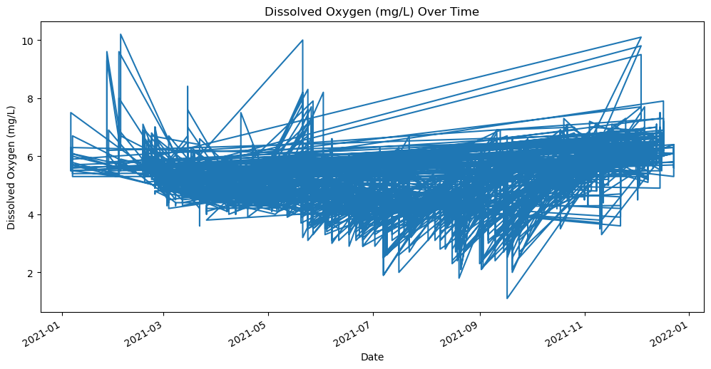

```python
# the date is the index now
data['Dissolved Oxygen (mg/L)'].plot(figsize=(12, 6))

plt.title('Dissolved Oxygen (mg/L) Over Time')
plt.xlabel('Date')
plt.ylabel('Dissolved Oxygen (mg/L)')
```

Create a similar plot for `Temperature (°C)`.

**Does the result make logical sense? That is, do warmer and colder temperatures occur at appropriate times of the year?**

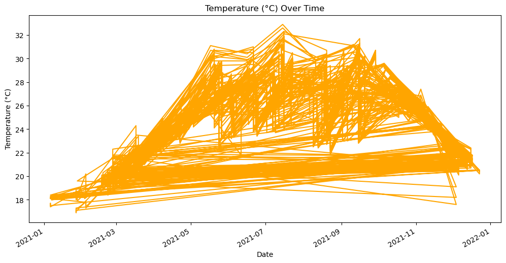

```python
data['Temperature (°C)'].plot(figsize=(12, 6), color='orange')
plt.title('Temperature (°C) Over Time')
plt.xlabel('Date')
plt.ylabel('Temperature (°C)')
```

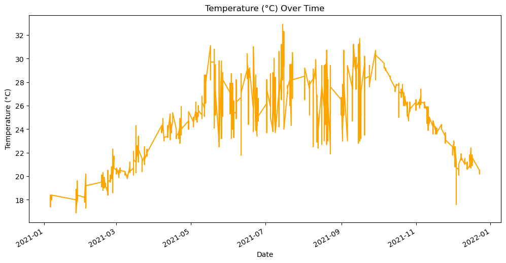

```python
data['Temperature (°C)'].sort_index().plot(figsize=(12, 6), color='orange')
plt.title('Temperature (°C) Over Time')
plt.xlabel('Date')
plt.ylabel('Temperature (°C)')
```

## Customising Plot Elements

Plot a time series of `'Dissolved Oxygen (mg/L)'` for the `DM1` **Station** using `pandas`. Ensure that the y-axis is labelled appropriately.

- You will need to rely on `plt.ylabel()`.

- See if you can also make each individual data point on the line to display as a downward-pointing triangle.
  - https://matplotlib.org/stable/api/markers_api.html

- Can you make the line **green**?

- Can you make the triangles **magenta** with **blue** edges?

- Can you control the **size** of the triangles?

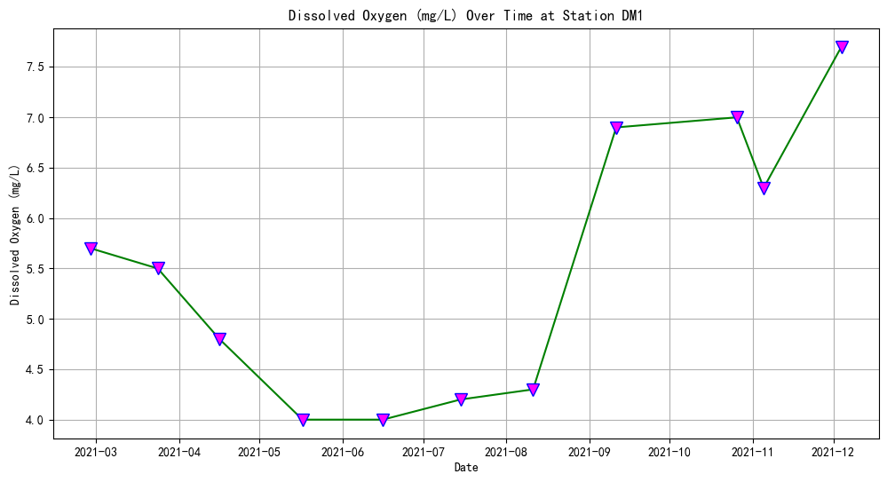

```python
dm1_data = data[data['Station'] == 'DM1']
fig, ax = plt.subplots(figsize=(12, 6))
ax.plot(dm1_data.index, dm1_data['Dissolved Oxygen (mg/L)'], marker='v', color='green',markerfacecolor='magenta', markeredgecolor='blue', markersize=10)

plt.title('Dissolved Oxygen (mg/L) Over Time at Station DM1')
plt.ylabel('Dissolved Oxygen (mg/L)')
plt.xlabel('Date')

plt.grid(True)
plt.show()
```

## `seaborn` Violin Plots

Use the **seaborn** `catplot` utility to create a set of **violin plots** describing the distribution of `pH` in each `Water Control Zone`.

Place the **categorical** variable along the x-axis and the **numerical** variable on the y-axis.

Investigate the `rotation` parameter associated with `set_xticklabels` to ensure that each label can easily be read. You might also find the `ha` parameter to provide more aesthetically pleasing results.

To modify the ticks, save the resulting plot object and use `set_` methods on that object.

See: https://matplotlib.org/stable/api/_as_gen/matplotlib.axes.Axes.set_xticklabels.html

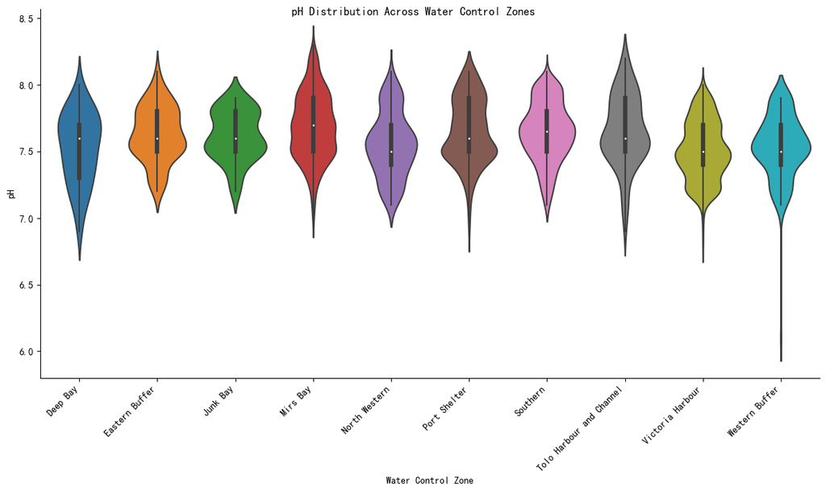

```python
g = sns.catplot(
    data=data,
    kind='violin',
    x='Water Control Zone',
    y='pH',
    height=6,
    aspect=2
)

# 旋转 x 轴标签
g.set_xticklabels(rotation=45, ha='right')

# 设置标题
g.fig.suptitle('pH Distribution Across Water Control Zones')

plt.show()
```

## `seaborn` Bar Plots

Use the **seaborn** `catplot` utility to create a group of **bar plots**. You will create an array of subplots (`catplot` can do this automagically) where each subplot (i.e., the `col` parameter), corresponding to individual `Water Control Zone` locations, displays the measurement of `'E. coli (cfu/100mL)'` in each month. The plotting routine will consider all entries with the same month name in the same water control zone. The bars will represent the mean measurement for each of these entries, and variability will be represented with a line through the end of the bar.

To organise the data by month, we will need to create a new `'Month'` column in the `DataFrame`. To do this, we will convert the time values in the `index` to **string abbreviations** for calendar months by using the `strftime` function with a suitable **format code**. See: https://docs.python.org/3/library/datetime.html#strftime-strptime-behavior

Appropriate representations will look like:

```
['Jan', 'Feb', 'Mar', 'Apr', 'May', 'Jun', 'Jul', 'Aug', 'Sep', 'Oct', 'Nov', 'Dec']
```

Try to display these neatly by using the `col_wrap` parameter and with the months displayed in time order from Jan-Dec by using the `order` parameter.

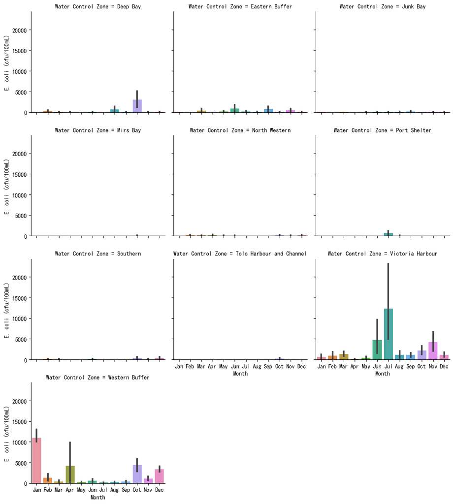

```python
data['Month'] = data.index.strftime('%b')
month_order = ['Jan', 'Feb', 'Mar', 'Apr', 'May', 'Jun',
               'Jul', 'Aug', 'Sep', 'Oct', 'Nov', 'Dec']
g = sns.catplot(data=data, x='Month', y='E. coli (cfu/100mL)', col='Water Control Zone', kind='bar', col_wrap=3, height=3, aspect=1.2, order=month_order)
```

## Comparing Zones

### Exploring the Data

We would like to **compare** how certain measurements change in time in different zones. Let's investigate how this might look for a specific measurement in a specific zone.

Create a **timeseries plot** of `'Salinity (psu)'` for `'Victoria Harbour'`. In this plot, **do not display the line** between the data points (e.g., `linestyle=''`). Instead, only show the data points as **circular markers**.

- Ensure your plot is reasonably labeled.

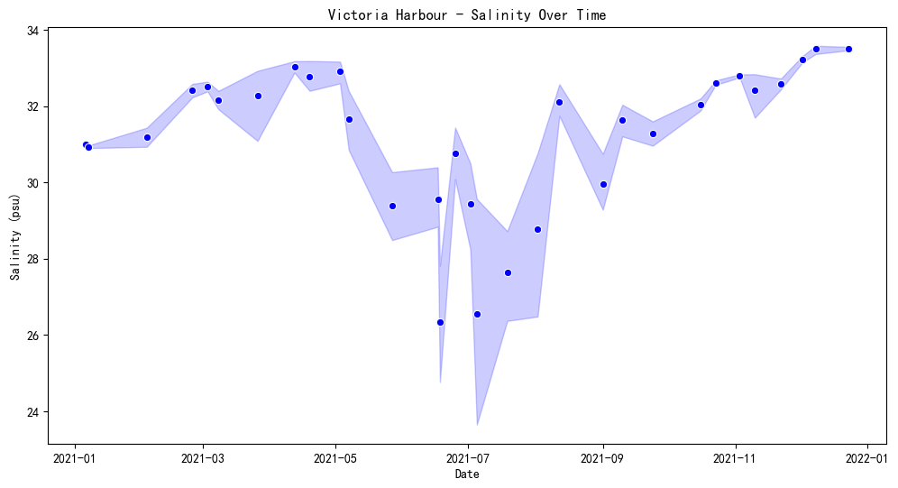

```python
vh_data = data[data['Water Control Zone'] == 'Victoria Harbour']
plt.figure(figsize=(12, 6))
sns.lineplot(x=vh_data.index, y=vh_data['Salinity (psu)'], color='blue', marker='o',linestyle='')

plt.xlabel('Date')
plt.ylabel('Salinity (psu)')
plt.title('Victoria Harbour - Salinity Over Time')
```

In the previous plot, it appears that there are many days without measurements and several days for which there are multiple measurements.

Confirm this suspicion by inspecting the `index` entries of the **entire** data set or a subset, such as specifically Victoria Harbour, or specific stations in Victoria Harbour.

- How many entries are present in the dataset?
- How many **unique** entries are present in the `index`?
- How many **duplicate** entries are present in the `index`?

```python
# For the entire dataset
total_entries = len(data)
unique_entries = data.index.unique()
duplicates = data.index.duplicated().sum()
print(f'Total entries: {total_entries}')
print(f'Unique entries: {len(unique_entries)}')
print(f'Duplicates: {duplicates}')
```

```
Total entries: 2708
Unique entries: 142
Duplicates: 2566
```

```python
# For Victoria Harbour
vh_data = data[data['Water Control Zone'] == 'Victoria Harbour']
total_entries = len(vh_data)
unique_entries = vh_data.index.unique()
duplicates = vh_data.index.duplicated().sum()
print(f'Total entries: {total_entries}')
print(f'Unique entries: {len(unique_entries)}')
print(f'Duplicates: {duplicates}')
```

```
Total entries: 438
Unique entries: 31
Duplicates: 407
```

```python
# Report the number of duplicated dates for each station in Victoria Harbour
duplicate_dates_by_station = vh_data.groupby('Station').apply(lambda x: x.index.duplicated().sum())
print(duplicate_dates_by_station)
```

```
Station
VM1     22
VM12    22
VM14    24
VM15    24
VM2     22
VM4     24
VM5     24
VM6     22
VM7     22
VM8     22
VT10     6
VT11    12
VT12     6
VT2      6
VT3      6
VT4     12
VT8      6
dtype: int32
```

### Reducing the Data

Now that we see that some days and stations have multiple measurements, let's **reduce** the total number of data points by averaging out the representation of multiple measurements and multiple stations.

**Group** the data by `'Water Control Zone'` and `'Dates'`. Then, **average** the grouped data to obtain average measurements for each zone on each date.

**Store** the result in a new object.

**Display** the resulting `DataFrame`.

```python
numerical_cols = data.select_dtypes(include=['float64', 'int64']).columns
non_numerical_cols = data.select_dtypes(exclude=['float64', 'int64']).columns

df = data.groupby(['Water Control Zone', 'Dates']).agg(
    {**{col: 'mean' for col in numerical_cols},  # average of numerical columns
       **{col: 'first' for col in non_numerical_cols}}
)

print(df.head(10))
```

```
                               Sample No  \
Water Control Zone Dates
Deep Bay           2021-01-28        1.0
                   2021-02-27        1.0
                   2021-03-24        1.0
                   2021-04-16        1.0
                   2021-05-17        1.0
                   2021-06-16        1.0
                   2021-07-15        1.0
                   2021-08-11        1.0
                   2021-09-11        1.0
                   2021-10-15        1.0

                               5-day Biochemical Oxygen Demand (mg/L)  \
Water Control Zone Dates
Deep Bay           2021-01-28                                  2.1000
                   2021-02-27                                  1.2500
                   2021-03-24                                  2.7750
                   2021-04-16                                  4.2125
                   2021-05-17                                  0.8875
                   2021-06-16                                  0.8500
                   2021-07-15                                  1.8875
                   2021-08-11                                  0.9500
                   2021-09-11                                  0.7875
                   2021-10-15                                  0.5800

                               Ammonia Nitrogen (mg/L)  Chlorophyll-a (μg/L)  \
Water Control Zone Dates
Deep Bay           2021-01-28                 0.100000               15.0000
                   2021-02-27                 0.181250                3.7625
                   2021-03-24                 0.165000               12.3250
                   2021-04-16                 0.142875               37.7875
                   2021-05-17                 0.055875                9.2375
                   2021-06-16                 0.098250                1.4750
                   2021-07-15                 0.062375                4.5000
                   2021-08-11                 0.349375                3.0125
                   2021-09-11                 0.161625                2.3625
                   2021-10-15                 0.348000                2.2400

                               Dissolved Oxygen (%saturation)  \
```

[output cut: 128 more lines]

```

                               Month
Water Control Zone Dates
Deep Bay           2021-01-28    Jan
                   2021-02-27    Feb
                   2021-03-24    Mar
                   2021-04-16    Apr
                   2021-05-17    May
                   2021-06-16    Jun
                   2021-07-15    Jul
                   2021-08-11    Aug
                   2021-09-11    Sep
                   2021-10-15    Oct

[10 rows x 29 columns]
```

### Reformatting the Data

In the previous result, you will see that the `index` now has two components: `'Water Control Zone'` and `'Dates'`. If you inspect the index, you will see that it is a `MultiIndex` object with a **hierarchical structure**.

You can use the `.unstack()` method on the `DataFrame` to **pivot** a level of the `MultiIndex` so that it will become the **inner** component of the column structure. - https://pandas.pydata.org/pandas-docs/version/2.2.2/reference/api/pandas.DataFrame.unstack.html

Let's focus on the `'Suspended Solids (mg/L)'` variable. Select this variable from the grouped and averaged data and **unstack** the Water Control Zone. By default, `unstack()` will operate on the *last* level, so you will need to specify the correct level by name or number.

**Display** the unstacked result. You should see zone names as columns and dates as the indices.

```python
df.index
```

```
MultiIndex([(      'Deep Bay', '2021-01-28'),
            (      'Deep Bay', '2021-02-27'),
            (      'Deep Bay', '2021-03-24'),
            (      'Deep Bay', '2021-04-16'),
            (      'Deep Bay', '2021-05-17'),
            (      'Deep Bay', '2021-06-16'),
            (      'Deep Bay', '2021-07-15'),
            (      'Deep Bay', '2021-08-11'),
            (      'Deep Bay', '2021-09-11'),
            (      'Deep Bay', '2021-10-15'),
            ...
            ('Western Buffer', '2021-06-11'),
            ('Western Buffer', '2021-07-07'),
            ('Western Buffer', '2021-07-12'),
            ('Western Buffer', '2021-08-21'),
            ('Western Buffer', '2021-09-02'),
            ('Western Buffer', '2021-09-06'),
            ('Western Buffer', '2021-10-11'),
            ('Western Buffer', '2021-11-01'),
            ('Western Buffer', '2021-11-08'),
            ('Western Buffer', '2021-12-08')],
           names=['Water Control Zone', 'Dates'], length=183)
```

```python
ss = df['Suspended Solids (mg/L)'].unstack(level = 'Water Control Zone')
print(ss)
```

```
Water Control Zone  Deep Bay  Eastern Buffer  Junk Bay  Mirs Bay  \
Dates
2021-01-06               NaN             1.9       1.8       NaN
2021-01-07               NaN             NaN       NaN       NaN
2021-01-27               NaN             NaN       NaN  0.633333
2021-01-28               5.7             NaN       NaN       NaN
2021-02-03               NaN             NaN       NaN       NaN
...                      ...             ...       ...       ...
2021-12-13               NaN             NaN       NaN       NaN
2021-12-15               NaN             NaN       NaN       NaN
2021-12-16               NaN             NaN       NaN  4.438889
2021-12-17               NaN             NaN       NaN       NaN
2021-12-23               NaN             NaN       NaN       NaN

Water Control Zone  North Western  Port Shelter  Southern  \
Dates
2021-01-06                    NaN      1.000000       NaN
2021-01-07                    NaN           NaN  3.833333
2021-01-27                    NaN           NaN       NaN
2021-01-28                    1.5           NaN       NaN
2021-02-03                    NaN           NaN  9.466667
...                           ...           ...       ...
2021-12-13                    NaN      4.362963       NaN
2021-12-15                    NaN           NaN       NaN
2021-12-16                    NaN           NaN       NaN
2021-12-17                    NaN           NaN  5.037500
2021-12-23                    NaN           NaN       NaN

Water Control Zone  Tolo Harbour and Channel  Victoria Harbour  Western Buffer
Dates
2021-01-06                               NaN          2.116667             NaN
2021-01-07                               NaN          4.150000        2.866667
2021-01-27                          0.200000               NaN             NaN
2021-01-28                               NaN               NaN             NaN
2021-02-03                               NaN          9.083333        8.466667
...                                      ...               ...             ...
2021-12-13                               NaN               NaN             NaN
2021-12-15                          6.173684               NaN             NaN
2021-12-16                               NaN               NaN             NaN
2021-12-17                               NaN               NaN             NaN
2021-12-23                               NaN          5.994444             NaN

[142 rows x 10 columns]
```

### Plot the Data

Inspecting the unstacked result, we see that there are many **missing values**. Most of these are the result of the fact that different Water Control Zones were **sampled on different dates**. The unstacked data now shows a row for every date in the suspended solids dataset, and a value is recorded for each zone and date, regardless of whether data was collected on that date.

We are interested in plotting the suspended solids time series for each zone on the same figure (a line for each zone).

Assuming your suspended solids data is now called `ss`, attempt to plot the data with `pandas` as:

```
ss.plot()
```

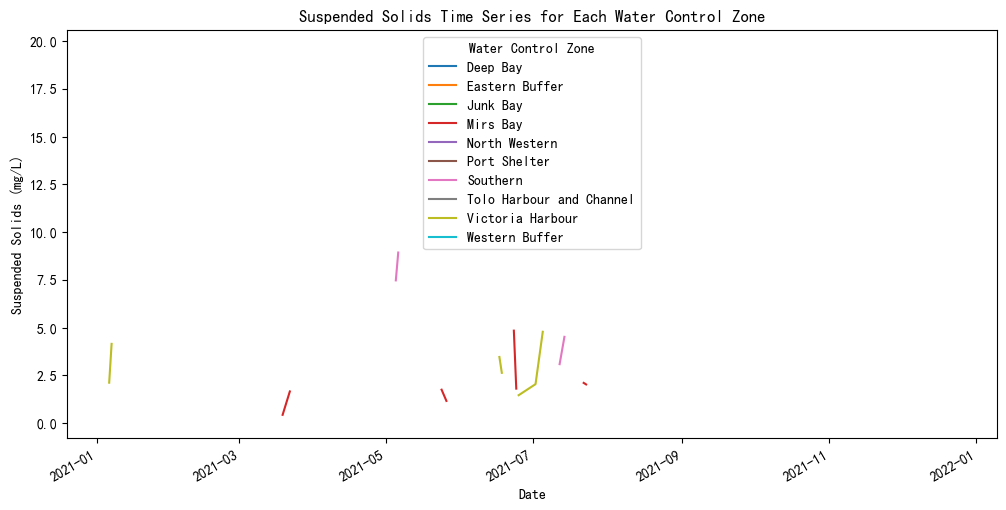

```python
ss.plot(figsize=(12, 6))
plt.title("Suspended Solids Time Series for Each Water Control Zone")
plt.xlabel("Date")
plt.ylabel("Suspended Solids (mg/L)")
```

### Adjust the Plot Legend

One obvious problem is that the **legend** is not in a very good location. We can relocate this by storing the resulting `AxesSubplot` object and modifying its associated legend information.

- `bbox_to_anchor` creates a new "bounding box" according to a tuple of spatial parameters.
  - The first two elements correspond to position (x, y) in relative axis units (0 to 1).
- `loc` specifies the legend location.

Legend info: https://matplotlib.org/stable/api/legend_api.html

Try:

```
ss.plot().legend(bbox_to_anchor=(1.04, 0.5), loc='center left')
```

Note: If you later save this figure, it is likely that the legend will not be fully inside the plot, as it likely extends outside of the original figure plotting region. One way to account for this is with an additional parameter in `savefig()`:

```
plt.savefig('figure.png', bbox_inches="tight")
```

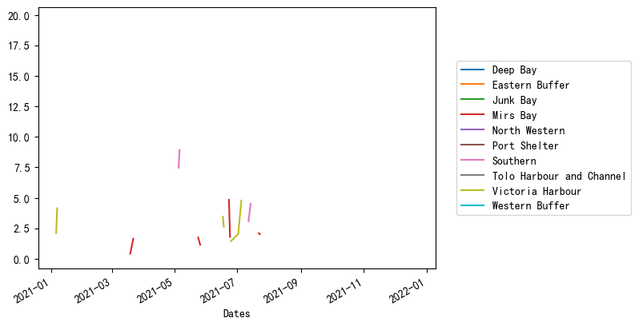

```python
ss.plot().legend(bbox_to_anchor=(1.04, 0.5), loc='center left')
plt.savefig('figure.png', bbox_inches='tight')
```

### Investigate the Plot Representation

The other major problem with this plot is that very little of the data is visible. Lines are only drawn between adjacent valid numbers. Everywhere that numbers are separated by NaNs, no line is drawn.

Re-plot the data with out drawn lines, only markers.

In the resulting figure, you should see many more data points than are depicted above.

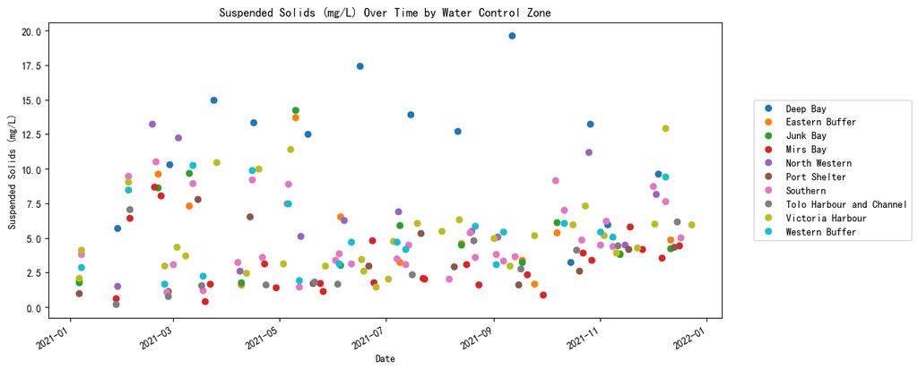

```python
ss.plot(figsize=(12, 6),lw=0, marker='o').legend(bbox_to_anchor=(1.04, 0.5), loc='center left')
plt.title('Suspended Solids (mg/L) Over Time by Water Control Zone')
plt.xlabel('Date')
plt.ylabel('Suspended Solids (mg/L)')
```

### Solution #1: `seaborn`

`seaborn`'s `lineplot()` works a bit differently: it will connect data points across the NaN values. Specify the `data` parameter to test this.

- The legend can be repositioned in the same way as for `pandas` plotting.

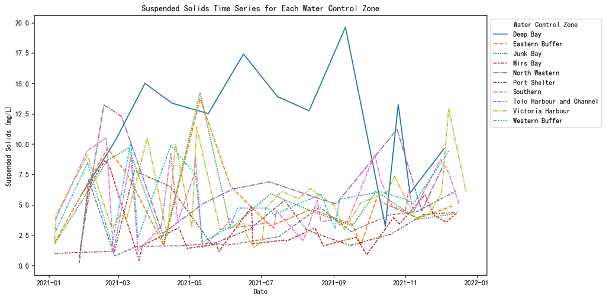

```python
plt.figure(figsize=(12, 6))
sns.lineplot(data=ss)
plt.title("Suspended Solids Time Series for Each Water Control Zone")
plt.xlabel("Date")
plt.ylabel("Suspended Solids (mg/L)")

plt.legend(title="Water Control Zone", loc='upper left', bbox_to_anchor=(1, 1))
plt.tight_layout()
plt.show()
```

### Solution #2: `matplotlib`

As an alternative to relying on `seaborn`, we could modify the data to make similar figures with `pandas` or `matplotlib`.

One way to do this is to **mask the missing values**.

Let's try this with `matplotlib`. Create a `for` loop over the column names (zones).

In the loop:

- Isolate the values in the column.
- Isolate the index values.
- Create a mask (`True`/`False`) of finite values (non-NaNs).
- Plot a line: masked indices, versus masked values.

After the loop:

- Adjust the legend.
- Add a y-label.

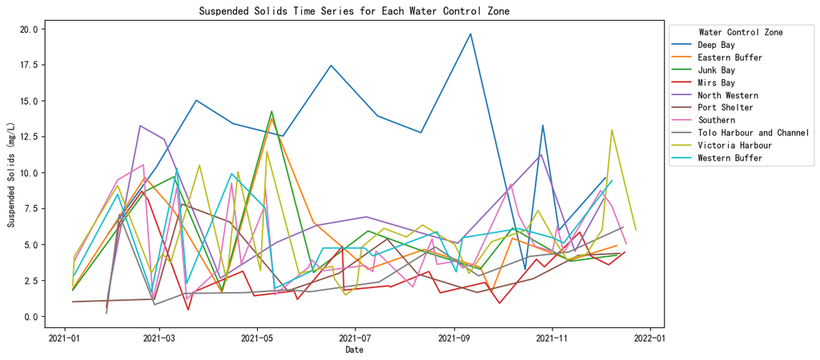

```python
plt.figure(figsize=(12, 6))

for zone in ss.columns:

    values = ss[zone]


    index = ss.index

    mask = np.isfinite(values)

    plt.plot(index[mask], values[mask], label=zone)

plt.title("Suspended Solids Time Series for Each Water Control Zone")
plt.xlabel("Date")
plt.ylabel("Suspended Solids (mg/L)")

plt.legend(title="Water Control Zone", loc='upper left', bbox_to_anchor=(1, 1))
```

### Solution #3: Interpolation

Another option is to **interpolate** between the known data points to **fill in the missing values**.

Let's try this with `seaborn`.

- To **linearly** interpolate the data in the columns, use the `pandas` method `df.interpolate()`.
  - See: https://pandas.pydata.org/pandas-docs/version/2.2.2/reference/api/pandas.DataFrame.interpolate.html
  - Test this without any arguments. **Can you determine why the lines look different?**
  - If you cannot determine what has gone wrong, check the description of the `method` parameter for `interpolate()`.
    - What is happening at the latest times for some of the zones? Why do the lines become horizontal?
  - Once you have sorted the issue, be sure to inspect the interpolated `DataFrame` to clearly understand how it has modified the data.
  - You might explore additional interpolation options. For this data, few others produce reasonable results.

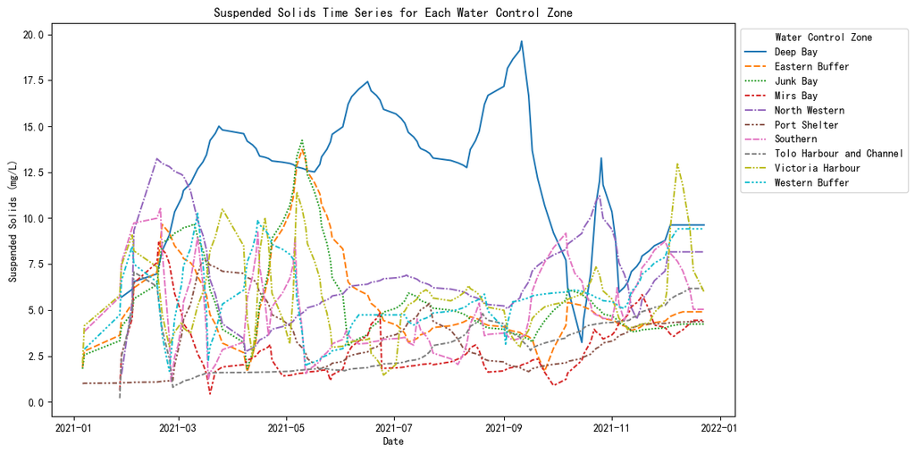

```python
plt.figure(figsize=(12, 6))
ss_interpolated = ss.interpolate(method='linear')
sns.lineplot(data=ss_interpolated)
plt.title("Suspended Solids Time Series for Each Water Control Zone")
plt.xlabel("Date")
plt.ylabel("Suspended Solids (mg/L)")

plt.legend(title="Water Control Zone", loc='upper left', bbox_to_anchor=(1, 1))
plt.tight_layout()
plt.show()
```

# Correlations and Heatmaps

The **`./data/longley.csv`** data set contains US macroeconomic variables measured over the middle of the last century. The variables are:

| Column | Description |
| --- | --- |
| GNP.deflator | GNP implicit price deflator (a measure of inflation) |
| GNP | Gross National Product |
| Unemployed | number of unemployed |
| Armed.Forces | number of people in the armed forces |
| Population | population with age older than 14 |
| Year | the year (1947 - 1962) |
| Employed | number of people employed |

**Explore the data and find which variables appear to be related.**

**Notes:**

- Take a look to the **correlation** function in the following link to review the relationship between variables.
  - https://pandas.pydata.org/pandas-docs/stable/reference/api/pandas.DataFrame.corr.html
  - Computes a pairwise correlation, comparing all of the columns in a `DataFrame` against one another..
- A good way to visualise correlation comparisons is with a **heatmap**. Please take a look to the following link to learn how to present the correlation between variables with this kind of graph.
  - https://seaborn.pydata.org/generated/seaborn.heatmap.html
  - Plots any rectangular dataset (like that produced by pairwise correlation).
  - Customise the display:
    - `cmap`: https://matplotlib.org/stable/tutorials/colors/colormaps.html (possibly something **diverging**)
    - `square`: Is the data this shape?
    - `annot`: write the data values on the plot
    - `vmin`,`vmax`: What should the range be?
    - `annot_kws={"fontsize":????}`: set the font size in the annotations (and other potential keyword arguments)
    - `linecolor`,`linewidths`: Do you want to add lines of some design?

```python
# Simple read of the data
longley = pd.read_csv('data/longley.csv')
longley
```

|  | GNP.deflator | GNP | Unemployed | Armed.Forces | Population | Year | Employed |
| --- | --- | --- | --- | --- | --- | --- | --- |
| 1947 | 83.0 | 234.289 | 235.6 | 159.0 | 107.608 | 1947 | 60.323 |
| 1948 | 88.5 | 259.426 | 232.5 | 145.6 | 108.632 | 1948 | 61.122 |
| 1949 | 88.2 | 258.054 | 368.2 | 161.6 | 109.773 | 1949 | 60.171 |
| 1950 | 89.5 | 284.599 | 335.1 | 165.0 | 110.929 | 1950 | 61.187 |
| 1951 | 96.2 | 328.975 | 209.9 | 309.9 | 112.075 | 1951 | 63.221 |
| 1952 | 98.1 | 346.999 | 193.2 | 359.4 | 113.270 | 1952 | 63.639 |
| 1953 | 99.0 | 365.385 | 187.0 | 354.7 | 115.094 | 1953 | 64.989 |
| 1954 | 100.0 | 363.112 | 357.8 | 335.0 | 116.219 | 1954 | 63.761 |
| 1955 | 101.2 | 397.469 | 290.4 | 304.8 | 117.388 | 1955 | 66.019 |
| 1956 | 104.6 | 419.180 | 282.2 | 285.7 | 118.734 | 1956 | 67.857 |
| 1957 | 108.4 | 442.769 | 293.6 | 279.8 | 120.445 | 1957 | 68.169 |
| 1958 | 110.8 | 444.546 | 468.1 | 263.7 | 121.950 | 1958 | 66.513 |
| 1959 | 112.6 | 482.704 | 381.3 | 255.2 | 123.366 | 1959 | 68.655 |
| 1960 | 114.2 | 502.601 | 393.1 | 251.4 | 125.368 | 1960 | 69.564 |
| 1961 | 115.7 | 518.173 | 480.6 | 257.2 | 127.852 | 1961 | 69.331 |
| 1962 | 116.9 | 554.894 | 400.7 | 282.7 | 130.081 | 1962 | 70.551 |

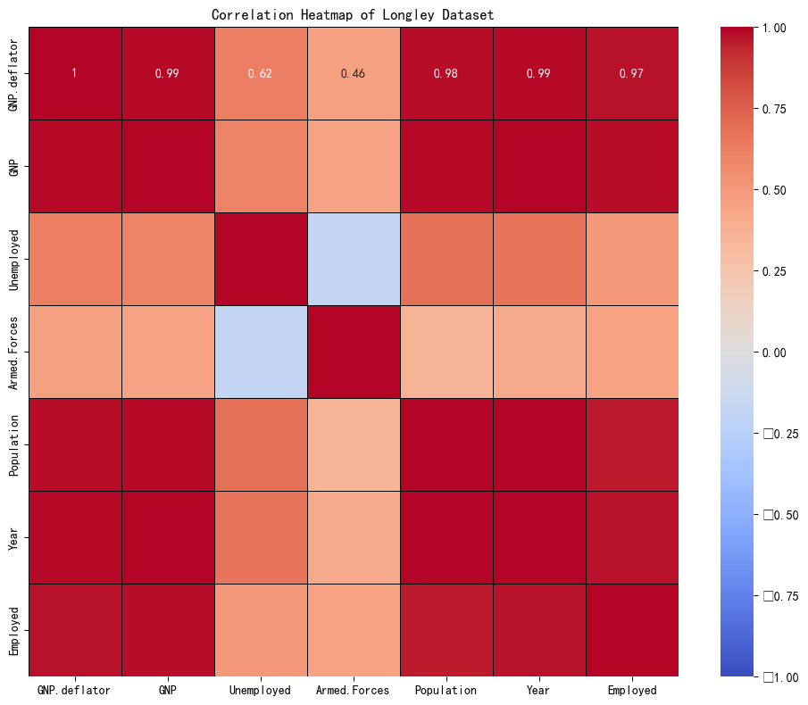

```python
# Compute the correlation matrix
corr_matrix = longley.corr()

# Plot the heatmap
plt.figure(figsize=(10, 8))
sns.heatmap(corr_matrix,
            annot=True,  # Display the correlation coefficients in each cell
            cmap='coolwarm',  # Use a diverging colormap (coolwarm) for contrast between negative and positive correlations
            square=True,  # Ensure the heatmap is square-shaped
            vmin=-1, vmax=1,  # Set the color scale limits from -1 to 1
            annot_kws={"fontsize": 10},  # Set the font size of the annotations
            linewidths=0.5,  # Set the width of the lines separating the cells
            linecolor='black')  # Set the color of the lines separating the cells

# Add title
plt.title("Correlation Heatmap of Longley Dataset")

# Display the heatmap
plt.tight_layout()  # Adjust the layout to ensure everything fits
plt.show()
```